# **Problem Statement**

## Business Context

A sales forecast is a prediction of future sales revenue based on historical data, industry trends, and the status of the current sales pipeline. Businesses use the sales forecast to estimate weekly, monthly, quarterly, and annual sales totals. A company needs to make an accurate sales forecast as it adds value across an organization and helps the different verticals to chalk out their future course of action.

Forecasting helps an organization plan its sales operations by region and provides valuable insights to the supply chain team regarding the procurement of goods and materials. An accurate sales forecast process has many benefits which include improved decision-making about the future and reduction of sales pipeline and forecast risks. Moreover, it helps to reduce the time spent in planning territory coverage and establish benchmarks that can be used to assess trends in the future.

## Objective

SuperKart is a retail chain operating supermarkets and food marts across various tier cities, offering a wide range of products. To optimize its inventory management and make informed decisions around regional sales strategies, SuperKart wants to accurately forecast the sales revenue of its outlets for the upcoming quarter.

To operationalize these insights at scale, the company has partnered with a data science firm—not just to build a predictive model based on historical sales data, but to develop and deploy a robust forecasting solution that can be integrated into SuperKart’s decision-making systems and used across its network of stores.

## Data Description

The data contains the different attributes of the various products and stores.The detailed data dictionary is given below.

- **Product_Id** - unique identifier of each product, each identifier having two letters at the beginning followed by a number.
- **Product_Weight** - weight of each product
- **Product_Sugar_Content** - sugar content of each product like low sugar, regular and no sugar
- **Product_Allocated_Area** - ratio of the allocated display area of each product to the total display area of all the products in a store
- **Product_Type** - broad category for each product like meat, snack foods, hard drinks, dairy, canned, soft drinks, health and hygiene, baking goods, bread, breakfast, frozen foods, fruits and vegetables, household, seafood, starchy foods, others
- **Product_MRP** - maximum retail price of each product
- **Store_Id** - unique identifier of each store
- **Store_Establishment_Year** - year in which the store was established
- **Store_Size** - size of the store depending on sq. feet like high, medium and low
- **Store_Location_City_Type** - type of city in which the store is located like Tier 1, Tier 2 and Tier 3. Tier 1 consists of cities where the standard of living is comparatively higher than its Tier 2 and Tier 3 counterparts.
- **Store_Type** - type of store depending on the products that are being sold there like Departmental Store, Supermarket Type 1, Supermarket Type 2 and Food Mart
- **Product_Store_Sales_Total** - total revenue generated by the sale of that particular product in that particular store

# **Installing and Importing the necessary libraries**

```python
#Installing the libraries with the specified versions
!pip install numpy==2.0.2 pandas==2.2.2 scikit-learn==1.6.1 matplotlib==3.10.0 seaborn==0.13.2 joblib==1.4.2 xgboost==2.1.4 requests==2.32.3 huggingface_hub==0.30.1 -q
```

[output not shown]

```python
!pip install streamlit requests
```

```
Downloading streamlit-1.52.2-py3-none-any.whl (9.0 MB)
   ━━━━━━━━━━━━━━━━━━━━━━━━━━━━━━━━━━━━━━━━ 9.0/9.0 MB 35.1 MB/s eta 0:00:00
Downloading pydeck-0.9.1-py2.py3-none-any.whl (6.9 MB)
   ━━━━━━━━━━━━━━━━━━━━━━━━━━━━━━━━━━━━━━━━ 6.9/6.9 MB 68.0 MB/s eta 0:00:00
```

**Note:**

- After running the above cell, kindly restart the notebook kernel (for Jupyter Notebook) or runtime (for Google Colab) and run all cells sequentially from the next cell.
- On executing the above line of code, you might see a warning regarding package dependencies. This error message can be ignored as the above code ensures that all necessary libraries and their dependencies are maintained to successfully execute the code in this notebook.

```python
import warnings
warnings.filterwarnings("ignore")

# Libraries to help with reading and manipulating data
import numpy as np
import pandas as pd

# For splitting the dataset
from sklearn.model_selection import train_test_split

# Libaries to help with data visualization
import matplotlib.pyplot as plt
import seaborn as sns

# Removes the limit for the number of displayed columns
pd.set_option("display.max_columns", None)
# Sets the limit for the number of displayed rows
pd.set_option("display.max_rows", 100)


# Libraries different ensemble classifiers
from sklearn.ensemble import (
    BaggingRegressor,
    RandomForestRegressor,
    AdaBoostRegressor,
    GradientBoostingRegressor,
)
from xgboost import XGBRegressor
from sklearn.tree import DecisionTreeRegressor, plot_tree

# Libraries to get different metric scores
from sklearn.metrics import (
    confusion_matrix,
    accuracy_score,
    precision_score,
    recall_score,
    f1_score,
    mean_squared_error,
    mean_absolute_error,
    r2_score,
    mean_absolute_percentage_error
)

# To create the pipeline
from sklearn.compose import make_column_transformer
from sklearn.pipeline import make_pipeline,Pipeline
from sklearn.compose import ColumnTransformer
from sklearn.pipeline import Pipeline
from sklearn.impute import SimpleImputer
from sklearn.preprocessing import LabelEncoder


# Classifiers
from sklearn.tree import DecisionTreeClassifier
from sklearn.ensemble import RandomForestClassifier, GradientBoostingClassifier
from sklearn.ensemble import AdaBoostClassifier, BaggingClassifier
from xgboost import XGBClassifier


# To tune different models and standardize
from sklearn.model_selection import GridSearchCV
from sklearn.preprocessing import StandardScaler,OneHotEncoder

# To serialize the model
import joblib

# os related functionalities
import os

# API request
import requests
from flask import Flask, request, jsonify




# for hugging face space authentication to upload files
from huggingface_hub import login, HfApi
```

# **Loading the dataset**

```python
from google.colab import files
uploaded = files.upload()
```

Upload widget is only available when the cell has been executed in the current browser session. Please rerun this cell to enable.

```
Saving SuperKart.csv to SuperKart.csv
```

# **Data Overview**

```python
df = pd.read_csv('SuperKart.csv')

print(df.shape)
df.head()
```

```
(8763, 12)
```

|  | Product_Id | Product_Weight | Product_Sugar_Content | Product_Allocated_Area | Product_Type | Product_MRP | Store_Id | Store_Establishment_Year | Store_Size | Store_Location_City_Type | Store_Type | Product_Store_Sales_Total |
| --- | --- | --- | --- | --- | --- | --- | --- | --- | --- | --- | --- | --- |
| 0 | FD6114 | 12.66 | Low Sugar | 0.027 | Frozen Foods | 117.08 | OUT004 | 2009 | Medium | Tier 2 | Supermarket Type2 | 2842.40 |
| 1 | FD7839 | 16.54 | Low Sugar | 0.144 | Dairy | 171.43 | OUT003 | 1999 | Medium | Tier 1 | Departmental Store | 4830.02 |
| 2 | FD5075 | 14.28 | Regular | 0.031 | Canned | 162.08 | OUT001 | 1987 | High | Tier 2 | Supermarket Type1 | 4130.16 |
| 3 | FD8233 | 12.10 | Low Sugar | 0.112 | Baking Goods | 186.31 | OUT001 | 1987 | High | Tier 2 | Supermarket Type1 | 4132.18 |
| 4 | NC1180 | 9.57 | No Sugar | 0.010 | Health and Hygiene | 123.67 | OUT002 | 1998 | Small | Tier 3 | Food Mart | 2279.36 |

### Observation:

The data contains 8763 rows and 12 columns.

```python
df.tail()
```

|  | Product_Id | Product_Weight | Product_Sugar_Content | Product_Allocated_Area | Product_Type | Product_MRP | Store_Id | Store_Establishment_Year | Store_Size | Store_Location_City_Type | Store_Type | Product_Store_Sales_Total |
| --- | --- | --- | --- | --- | --- | --- | --- | --- | --- | --- | --- | --- |
| 8758 | NC7546 | 14.80 | No Sugar | 0.016 | Health and Hygiene | 140.53 | OUT004 | 2009 | Medium | Tier 2 | Supermarket Type2 | 3806.53 |
| 8759 | NC584 | 14.06 | No Sugar | 0.142 | Household | 144.51 | OUT004 | 2009 | Medium | Tier 2 | Supermarket Type2 | 5020.74 |
| 8760 | NC2471 | 13.48 | No Sugar | 0.017 | Health and Hygiene | 88.58 | OUT001 | 1987 | High | Tier 2 | Supermarket Type1 | 2443.42 |
| 8761 | NC7187 | 13.89 | No Sugar | 0.193 | Household | 168.44 | OUT001 | 1987 | High | Tier 2 | Supermarket Type1 | 4171.82 |
| 8762 | FD306 | 14.73 | Low Sugar | 0.177 | Snack Foods | 224.93 | OUT002 | 1998 | Small | Tier 3 | Food Mart | 2186.08 |

```python
df.info()
```

```
<class 'pandas.core.frame.DataFrame'>
RangeIndex: 8763 entries, 0 to 8762
Data columns (total 12 columns):
 #   Column                     Non-Null Count  Dtype
---  ------                     --------------  -----
 0   Product_Id                 8763 non-null   object
 1   Product_Weight             8763 non-null   float64
 2   Product_Sugar_Content      8763 non-null   object
 3   Product_Allocated_Area     8763 non-null   float64
 4   Product_Type               8763 non-null   object
 5   Product_MRP                8763 non-null   float64
 6   Store_Id                   8763 non-null   object
 7   Store_Establishment_Year   8763 non-null   int64
 8   Store_Size                 8763 non-null   object
 9   Store_Location_City_Type   8763 non-null   object
 10  Store_Type                 8763 non-null   object
 11  Product_Store_Sales_Total  8763 non-null   float64
dtypes: float64(4), int64(1), object(7)
memory usage: 821.7+ KB
```

### Observation:

- The dataset contains **8,763 records** with **12 features**, indicating a reasonably sized dataset suitable for both **model training and deployment testing**.
- **No missing values** are present in any column (all columns have 8,763 non-null entries), which confirms **high data integrity** and eliminates the need for imputation during preprocessing.
- The data includes a balanced mix of:
  - **Numerical features** (`float64`, `int64`):
    - *Product_Weight, Product_Allocated_Area, Product_MRP, Product_Store_Sales_Total*
    - *Store_Establishment_Year*
  - **Categorical features** (`object`):
    - *Product_Id, Product_Sugar_Content, Product_Type, Store_Id, Store_Size, Store_Location_City_Type, Store_Type*
- The presence of **multiple categorical variables** indicates the necessity of **encoding strategies** (e.g., One-Hot Encoding or Target Encoding) before model training and deployment.
- The **target variable** (*Product_Store_Sales_Total*) is continuous and numerical, confirming that this is a **regression problem**.
- Memory usage (~**822 KB**) is low, which is advantageous for:
  - **Fast model training**
  - **Efficient API inference**
  - **Lightweight deployment in production environments**

**Conclusion:** The dataset is **clean, well-structured, and deployment-ready**, requiring only standard preprocessing (categorical encoding and scaling if needed). Its size and quality make it suitable for building a **robust regression model** and deploying it efficiently in a real-time or batch prediction pipeline.

```python
print("\nData types:")
print(df.dtypes)
```

```
Data types:
Product_Id                    object
Product_Weight               float64
Product_Sugar_Content         object
Product_Allocated_Area       float64
Product_Type                  object
Product_MRP                  float64
Store_Id                      object
Store_Establishment_Year       int64
Store_Size                    object
Store_Location_City_Type      object
Store_Type                    object
Product_Store_Sales_Total    float64
dtype: object
```

### Observation:

The data types are appropriate and logically assigned, clearly defining a regression problem with mixed data inputs. Successful model deployment will depend on robust categorical encoding, feature transformation, and consistent preprocessing pipelines between training and production environments.

```python
df.isnull().sum()
```

|  | 0 |
| --- | --- |
| Product_Id | 0 |
| Product_Weight | 0 |
| Product_Sugar_Content | 0 |
| Product_Allocated_Area | 0 |
| Product_Type | 0 |
| Product_MRP | 0 |
| Store_Id | 0 |
| Store_Establishment_Year | 0 |
| Store_Size | 0 |
| Store_Location_City_Type | 0 |
| Store_Type | 0 |
| Product_Store_Sales_Total | 0 |

**dtype:** int64

### Observation:

The dataset is complete and robust, with no missing values across any feature. This significantly improves model reliability, training stability, and deployment readiness, allowing the focus to remain on feature engineering and model optimization rather than data cleaning.

```python
df.duplicated().sum()
```

```
np.int64(0)
```

### Observation:

The absence of duplicate records confirms that the dataset is clean, unbiased, and suitable for robust model training and deployment, strengthening confidence in downstream model performance and evaluation results.

```python
df.describe()
```

|  | Product_Weight | Product_Allocated_Area | Product_MRP | Store_Establishment_Year | Product_Store_Sales_Total |
| --- | --- | --- | --- | --- | --- |
| count | 8763.000000 | 8763.000000 | 8763.000000 | 8763.000000 | 8763.000000 |
| mean | 12.653792 | 0.068786 | 147.032539 | 2002.032751 | 3464.003640 |
| std | 2.217320 | 0.048204 | 30.694110 | 8.388381 | 1065.630494 |
| min | 4.000000 | 0.004000 | 31.000000 | 1987.000000 | 33.000000 |
| 25% | 11.150000 | 0.031000 | 126.160000 | 1998.000000 | 2761.715000 |
| 50% | 12.660000 | 0.056000 | 146.740000 | 2009.000000 | 3452.340000 |
| 75% | 14.180000 | 0.096000 | 167.585000 | 2009.000000 | 4145.165000 |
| max | 22.000000 | 0.298000 | 266.000000 | 2009.000000 | 8000.000000 |

### Observation:

- The summary statistics cover **8,763 observations** for all numerical variables, confirming **complete numerical data consistency**.

#### Feature-wise Interpretation

- **Product_Weight**
  - Mean (~ 12.65) and median (~12.66) are nearly identical, indicating a **symmetrical distribution**.
  - Values range from **4 to 22**, suggesting reasonable product weight variability with **no extreme outliers**.
- **Product_Allocated_Area**
  - Mean (~ 0.069) is higher than the median (~0.056), indicating a **right-skewed distribution**.
  - The wide spread between min (0.004) and max (0.298) suggests that **shelf space allocation varies significantly**, which may strongly influence sales.
- **Product_MRP**
  - Mean (~ 147) and median (~147) are closely aligned, showing a **well-centered price distribution**.
  - The price range (**31 to 266**) reflects **diverse product pricing**, which is a key driver of sales behavior.
- **Store_Establishment_Year**
  - Most stores were established between **1998 and 2009**, with a median of **2009**.
  - The relatively small standard deviation (~8.4 years) suggests **limited variability in store age**, which may reduce its standalone predictive power unless transformed (e.g., store age).
- **Product_Store_Sales_Total (Target Variable)**
  - The target shows **high variability** (std ≈ 1,066) with sales ranging from **33 to 8,000**.
  - Mean and median are close, indicating a **fairly balanced distribution**, but the wide range suggests potential **high-revenue and low-revenue product segments**.

#### Modeling & Deployment Implications

- The absence of extreme outliers in numerical features reduces the need for aggressive outlier treatment.
- Differences in feature scales (e.g., allocated area vs. MRP) suggest that:
  - **Feature scaling** (StandardScaler or MinMaxScaler) may benefit distance-based models.
- High variability in the target variable reinforces the importance of:
  - Robust evaluation metrics (RMSE, MAE, R²)
  - Careful monitoring during deployment to detect prediction drift.

**Conclusion:** The numerical features are **well-distributed, realistic, and informative**, providing a strong foundation for regression modeling. The statistics indicate **stable data quality**, while also highlighting key business drivers—pricing, shelf allocation, and store characteristics—that are likely to influence sales performance in the deployed SuperKart model.

```python
# Identify numerical and categorical columns
numerical_cols = df.select_dtypes(include=[np.number]).columns.tolist()
categorical_cols = df.select_dtypes(exclude=[np.number]).columns.tolist()

# Print results
print("Total Columns:", df.shape[1])
print("\nNumber of Numerical Columns:", len(numerical_cols))
print("Numerical Columns:")
for col in numerical_cols:
    print(f" - {col}")

print("\nNumber of Categorical Columns:", len(categorical_cols))
print("Categorical Columns:")
for col in categorical_cols:
    print(f" - {col}")
```

```
Total Columns: 12

Number of Numerical Columns: 5
Numerical Columns:
 - Product_Weight
 - Product_Allocated_Area
 - Product_MRP
 - Store_Establishment_Year
 - Product_Store_Sales_Total

Number of Categorical Columns: 7
Categorical Columns:
 - Product_Id
 - Product_Sugar_Content
 - Product_Type
 - Store_Id
 - Store_Size
 - Store_Location_City_Type
 - Store_Type
```

### Observation:

- The dataset consists of **12 total columns**, clearly divided into:
  - **5 numerical features**
  - **7 categorical features**

#### Numerical Features

- *Product_Weight, Product_Allocated_Area, Product_MRP* → Continuous product-level attributes directly influencing pricing and demand.
- *Store_Establishment_Year* → Temporal store characteristic that may better capture behavior when transformed into **store age**.
- *Product_Store_Sales_Total* → The **target variable**, confirming a **regression modeling objective**.

#### Categorical Features

- *Product_Id, Store_Id* → Identifier-based features with potentially **high cardinality**, requiring careful handling to avoid overfitting.
- *Product_Sugar_Content, Product_Type* → Product attributes useful for segmenting customer demand.
- *Store_Size, Store_Location_City_Type, Store_Type* → Store-level characteristics likely to influence footfall and sales volume.

#### Modeling & Deployment Implications

- The **high proportion of categorical features** emphasizes the importance of:
  - Consistent **encoding strategies** during training and inference.
  - Saving the preprocessing pipeline for deployment to prevent feature mismatch.
- Numerical features may require **scaling**, especially for linear or distance-based models.
- The clear separation of feature types simplifies:
  - Automated preprocessing pipelines
  - Input schema validation in deployed APIs

**Conclusion:** The dataset demonstrates a **well-defined mix of numerical and categorical features**, aligning with real-world retail data. This structure supports building a **robust, production-ready regression model**, provided that categorical encoding and preprocessing are handled consistently across training and deployment environments.

# **Exploratory Data Analysis (EDA)**

## Univariate Analysis

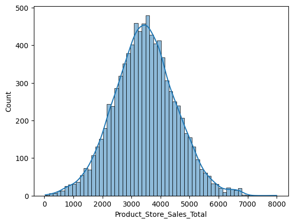

```python
# Distribution of Target Variable
sns.histplot(df['Product_Store_Sales_Total'], kde=True)
plt.show()
```

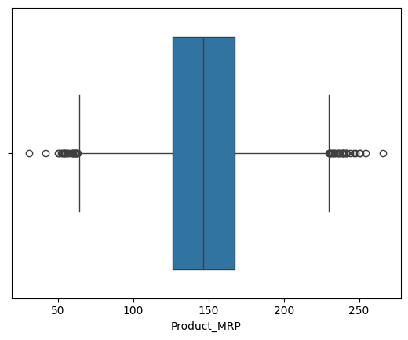

```python
# Boxplot – Product MRP
sns.boxplot(x=df['Product_MRP'])
plt.show()
```

```python
# Summary of categorical columns
print(df.describe(include="object"))
```

```
       Product_Id Product_Sugar_Content           Product_Type Store_Id  \
count        8763                  8763                   8763     8763
unique       8763                     4                     16        4
top         FD306             Low Sugar  Fruits and Vegetables   OUT004
freq            1                  4885                   1249     4676

       Store_Size Store_Location_City_Type         Store_Type
count        8763                     8763               8763
unique          3                        3                  4
top        Medium                   Tier 2  Supermarket Type2
freq         6025                     6262               4676
```

### Observation:

The summary statistics of categorical variables provide valuable insights into **cardinality, dominance patterns, and encoding considerations**.

#### Feature-wise Interpretation

- **Product_Id**
  - *Unique values*: **8,763 (100% unique)**
  - Each product appears exactly once, indicating this is a **pure identifier** rather than a predictive feature.
  - Including it directly in modeling may **add noise without predictive value** and increase deployment complexity.
- **Product_Sugar_Content**
  - *4 distinct categories* with **“Low Sugar” dominating (~56%)**
  - This imbalance suggests:
    - Strong market preference or labeling bias
    - The feature remains informative but should be monitored for **category imbalance effects**.
- **Product_Type**
  - *16 categories* with **“Fruits and Vegetables” as the most frequent**
  - Moderate cardinality makes it suitable for **One-Hot Encoding** without excessive dimensionality.
- **Store_Id**
  - *4 unique stores*, with **OUT004 accounting for more than half of the data**
  - This skew indicates **store-level dominance**, which can significantly influence sales predictions.
- **Store_Size**
  - *3 categories*, heavily dominated by **“Medium” stores**
  - Low cardinality and strong interpretability make it an excellent candidate for encoding.
- **Store_Location_City_Type**
  - *3 tiers*, with **Tier 2 representing the majority**
  - Reflects realistic urban distribution and is likely to be a strong sales driver.
- **Store_Type**
  - *4 categories*, dominated by **“Supermarket Type2”**
  - Suggests operational scale differences across store types that can influence revenue.

#### Modeling & Deployment Implications

- High-cardinality identifier columns (*Product_Id*) should be:
  - Excluded from modeling or
  - Used only for tracking, not prediction
- Low-to-moderate cardinality features are:
  - Ideal for **One-Hot Encoding**
  - Stable and safe for deployment pipelines
- Dominant categories indicate:
  - Potential **class imbalance**, which should be considered when interpreting feature importance

**Conclusion:** The categorical variables exhibit **clear dominance patterns and manageable cardinality**, aligning well with retail business dynamics. Careful feature selection—especially excluding pure identifiers—combined with consistent encoding will ensure a **robust, interpretable, and deployment-ready SuperKart sales prediction model**.

```
Distribution of Product_Id:
```

| Product_Id | Count | Percentage (%) |
| --- | --- | --- |
| FD306 | 1 | 0.011412 |
| FD6114 | 1 | 0.011412 |
| FD7839 | 1 | 0.011412 |
| FD5075 | 1 | 0.011412 |
| FD8233 | 1 | 0.011412 |
| ... | ... | ... |
| FD1387 | 1 | 0.011412 |
| FD1231 | 1 | 0.011412 |
| FD5276 | 1 | 0.011412 |
| FD8553 | 1 | 0.011412 |
| FD6027 | 1 | 0.011412 |

8763 rows × 2 columns

```
Distribution of Product_Sugar_Content:
```

| Product_Sugar_Content | Count | Percentage (%) |
| --- | --- | --- |
| Low Sugar | 4885 | 55.745749 |
| Regular | 2251 | 25.687550 |
| No Sugar | 1519 | 17.334246 |
| reg | 108 | 1.232455 |

```
Distribution of Product_Type:
```

| Product_Type | Count | Percentage (%) |
| --- | --- | --- |
| Fruits and Vegetables | 1249 | 14.253110 |
| Snack Foods | 1149 | 13.111948 |
| Frozen Foods | 811 | 9.254821 |
| Dairy | 796 | 9.083647 |
| Household | 740 | 8.444597 |
| Baking Goods | 716 | 8.170718 |
| Canned | 677 | 7.725665 |
| Health and Hygiene | 628 | 7.166495 |
| Meat | 618 | 7.052379 |
| Soft Drinks | 519 | 5.922629 |
| Breads | 200 | 2.282323 |
| Hard Drinks | 186 | 2.122561 |
| Others | 151 | 1.723154 |
| Starchy Foods | 141 | 1.609038 |
| Breakfast | 106 | 1.209631 |
| Seafood | 76 | 0.867283 |

```
Distribution of Store_Id:
```

| Store_Id | Count | Percentage (%) |
| --- | --- | --- |
| OUT004 | 4676 | 53.360721 |
| OUT001 | 1586 | 18.098825 |
| OUT003 | 1349 | 15.394271 |
| OUT002 | 1152 | 13.146183 |

```
Distribution of Store_Size:
```

| Store_Size | Count | Percentage (%) |
| --- | --- | --- |
| Medium | 6025 | 68.754993 |
| High | 1586 | 18.098825 |
| Small | 1152 | 13.146183 |

```
Distribution of Store_Location_City_Type:
```

| Store_Location_City_Type | Count | Percentage (%) |
| --- | --- | --- |
| Tier 2 | 6262 | 71.459546 |
| Tier 1 | 1349 | 15.394271 |
| Tier 3 | 1152 | 13.146183 |

```
Distribution of Store_Type:
```

| Store_Type | Count | Percentage (%) |
| --- | --- | --- |
| Supermarket Type2 | 4676 | 53.360721 |
| Supermarket Type1 | 1586 | 18.098825 |
| Departmental Store | 1349 | 15.394271 |
| Food Mart | 1152 | 13.146183 |

[figure not shown]

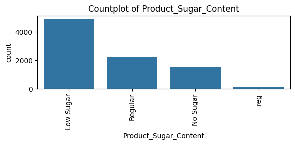

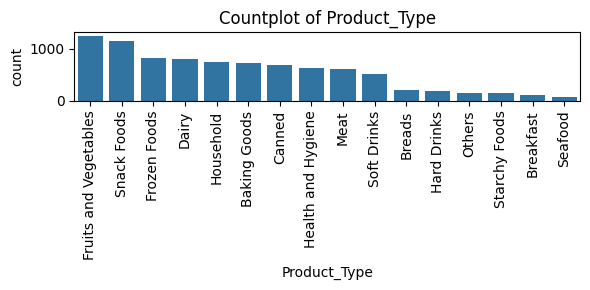

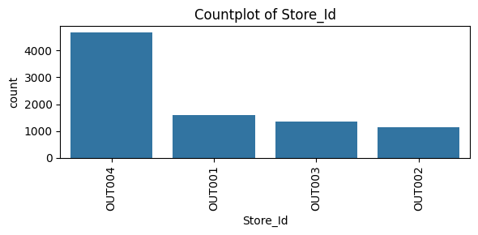

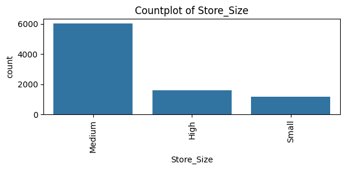

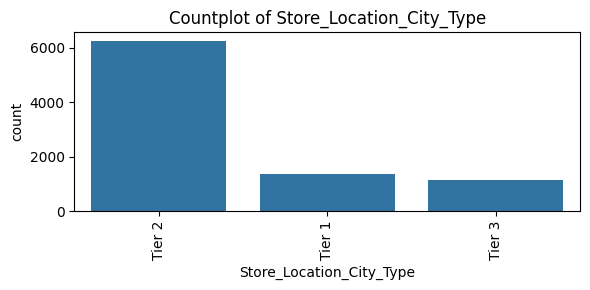

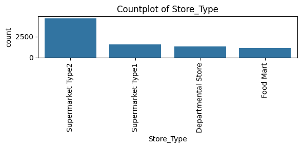

```python
# Count and percentage distribution for categorical variables
categorical_cols = df.select_dtypes(include='object').columns

for col in categorical_cols:
    summary = (
        df[col]
        .value_counts()
        .to_frame(name='Count')
    )
    summary['Percentage (%)'] = (summary['Count'] / len(df)) * 100

    print(f"\nDistribution of {col}:")
    display(summary)


for col in categorical_cols:
    plt.figure(figsize=(6, 3))
    sns.countplot(data=df, x=col, order=df[col].value_counts().index)
    plt.title(f'Countplot of {col}')
    plt.xticks(rotation=90, fontsize=10)
    plt.tight_layout()
    plt.show()
```

### Observation:

The tabular distributions provide a **clear numerical equivalent of the countplots**, enabling precise interpretation of categorical patterns and their impact on modeling and deployment.

## Product-Level Categorical Features

### **Product_Id**

- All **8,763 Product_Id values are unique**, each contributing **~0.01%** of the data.
- This confirms that *Product_Id* is a **pure identifier** with **no repeat observations**.
- **Modeling implication:**
  - Including this feature would add **noise and unnecessary dimensionality**.
  - It should be **excluded from training** and retained only for record tracking or output mapping in deployment.

### **Product_Sugar_Content**

- Strong dominance of **“Low Sugar” (55.75%)**
- “Regular” (25.69%) and “No Sugar” (17.33%) form substantial secondary segments.
- Minor inconsistency observed: **“reg” (1.23%)**
- **Data quality insight:**
  - “reg” is likely a **labeling inconsistency** and should be merged with “Regular”.
- **Business insight:**
  - Indicates strong consumer preference or product positioning toward **low-sugar items**.

### **Product_Type**

- Well-distributed across **16 categories**, led by:
  - Fruits and Vegetables (14.25%)
  - Snack Foods (13.11%)
  - Frozen Foods (9.25%)
  - Dairy (9.08%)
- No single category dominates excessively.
- **Modeling implication:**
  - This feature is **highly informative** and suitable for One-Hot Encoding.
  - It is likely to be a **key driver of sales variation**.

## Store-Level Categorical Features

### **Store_Id**

- Strong dominance of **OUT004 (53.36%)**
- Remaining stores are reasonably represented.
- **Insight:**
  - Store-specific characteristics significantly influence sales.
- **Deployment implication:**
  - Model predictions may be **biased toward dominant stores**.
  - Monitor performance carefully if new stores are introduced.

### **Store_Size**

- **Medium-sized stores dominate (68.75%)**
- High (18.10%) and Small (13.15%) stores are less common.
- **Interpretation:**
  - Medium stores likely represent the **core business format**.
- Suitable for categorical encoding with low risk of sparsity.

### **Store_Location_City_Type**

- **Tier 2 cities dominate (71.46%)**
- Tier 1 (15.39%) and Tier 3 (13.15%) have similar representation.
- **Business insight:**
  - Sales performance is likely influenced by **urban density and purchasing power**.
- **Modeling implication:**
  - Feature is informative but **imbalanced**, requiring careful interpretation.

### **Store_Type**

- **Supermarket Type2** dominates (53.36%)
- Remaining types are well distributed.
- **Insight:**
  - Operational differences across store types are expected to impact sales volume.

## Modeling & Deployment Implications

- **High-cardinality identifiers** (*Product_Id*) should be excluded from training.
- **Low-to-moderate cardinality features** are:
  - Stable for encoding
  - Suitable for production deployment
- **Category imbalance** exists in several features:
  - Acceptable for regression
  - Requires monitoring for **prediction bias** post-deployment
- **Data cleaning action required**:
  - Merge *“reg” → “Regular”* in *Product_Sugar_Content*

**Conclusion:** The categorical distributions reveal **clear business patterns and stable feature structures** typical of retail datasets. With minor data cleaning and consistent encoding, these variables provide **strong predictive power** while remaining **safe and interpretable for production deployment** in the SuperKart sales prediction system.

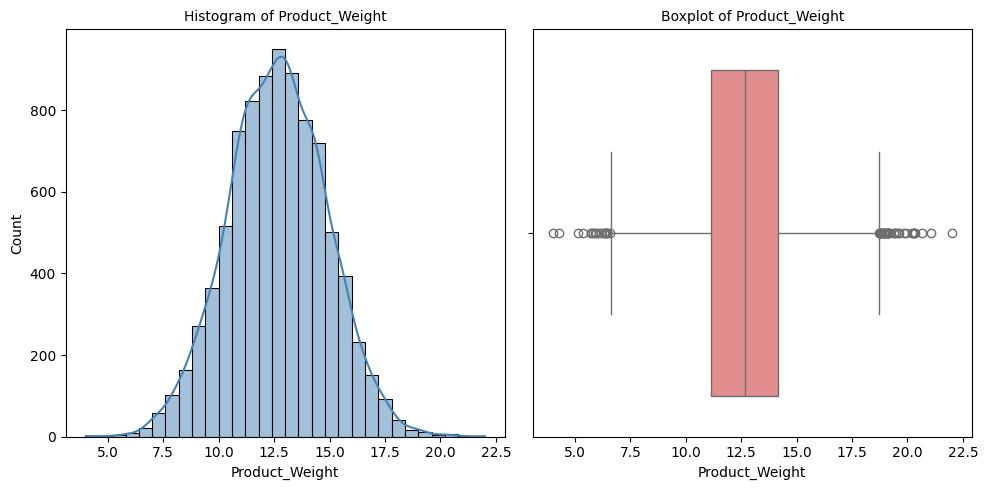

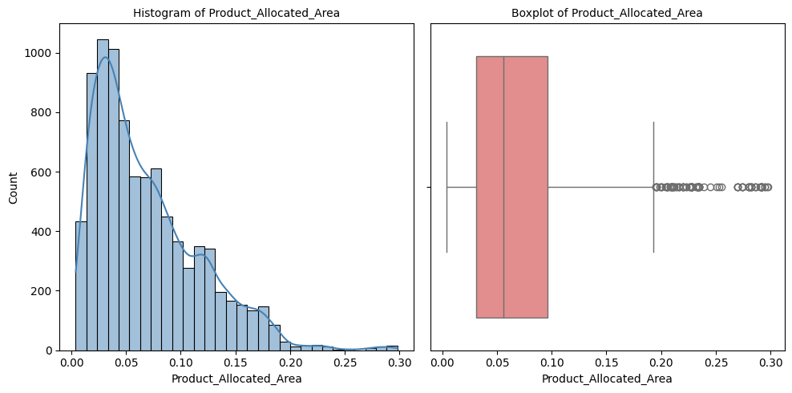

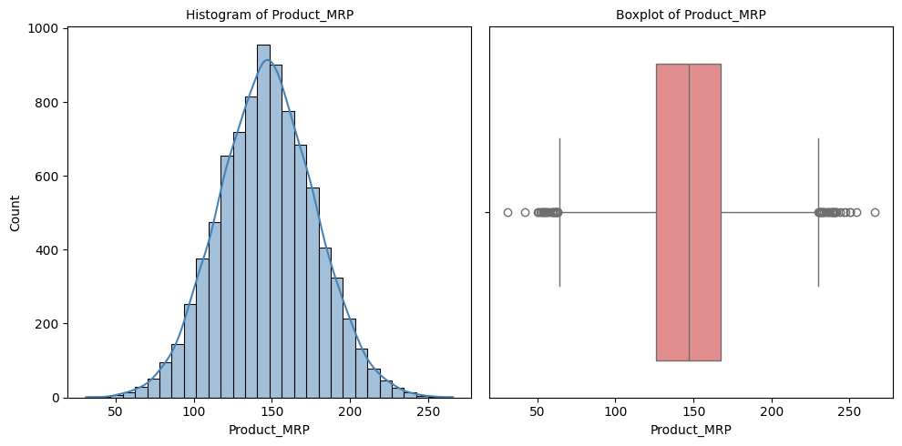

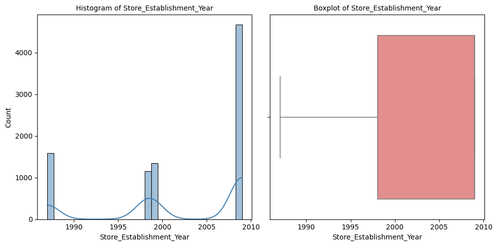

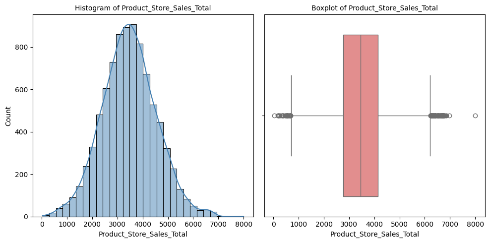

```python
#Explore Numerical Variables
numerical_cols = df.select_dtypes(include=['int64', 'float64']).columns


for col in numerical_cols:
    plt.figure(figsize=(10, 5))

    # Histogram
    plt.subplot(1, 2, 1)
    sns.histplot(df[col], kde=True, bins=30, color="steelblue")
    plt.title(f'Histogram of {col}',fontsize=10)

    # Boxplot
    plt.subplot(1, 2, 2)
    sns.boxplot(x=df[col], color="lightcoral")
    plt.title(f'Boxplot of {col}',fontsize=10)

    plt.tight_layout()
    plt.show()
```

```python
numerical_cols = df.select_dtypes(include=['int64', 'float64']).columns

summary_list = []

for col in numerical_cols:
    Q1 = df[col].quantile(0.25)
    Q3 = df[col].quantile(0.75)
    IQR = Q3 - Q1

    lower_bound = Q1 - 1.5 * IQR
    upper_bound = Q3 + 1.5 * IQR

    outliers = df[(df[col] < lower_bound) | (df[col] > upper_bound)][col].count()

    summary_list.append({
        "Feature": col,
        "Mean": df[col].mean(),
        "Median": df[col].median(),
        "Std Dev": df[col].std(),
        "Skewness": df[col].skew(),
        "Kurtosis": df[col].kurtosis(),
        "IQR": IQR,
        "Lower Bound (Boxplot)": lower_bound,
        "Upper Bound (Boxplot)": upper_bound,
        "Outlier Count": outliers,
        "Min": df[col].min(),
        "Max": df[col].max()
    })

numerical_distribution_summary = pd.DataFrame(summary_list)
display(numerical_distribution_summary)
```

|  | Feature | Mean | Median | Std Dev | Skewness | Kurtosis | IQR | Lower Bound (Boxplot) | Upper Bound (Boxplot) | Outlier Count | Min | Max |
| --- | --- | --- | --- | --- | --- | --- | --- | --- | --- | --- | --- | --- |
| 0 | Product_Weight | 12.653792 | 12.660 | 2.217320 | 0.017514 | 0.004569 | 3.030 | 6.6050 | 18.7250 | 54 | 4.000 | 22.000 |
| 1 | Product_Allocated_Area | 0.068786 | 0.056 | 0.048204 | 1.128093 | 1.293136 | 0.065 | -0.0665 | 0.1935 | 104 | 0.004 | 0.298 |
| 2 | Product_MRP | 147.032539 | 146.740 | 30.694110 | 0.036513 | -0.011590 | 41.425 | 64.0225 | 229.7225 | 57 | 31.000 | 266.000 |
| 3 | Store_Establishment_Year | 2002.032751 | 2009.000 | 8.388381 | -0.758061 | -0.868945 | 11.000 | 1981.5000 | 2025.5000 | 0 | 1987.000 | 2009.000 |
| 4 | Product_Store_Sales_Total | 3464.003640 | 3452.340 | 1065.630494 | 0.092024 | 0.152406 | 1383.450 | 686.5400 | 6220.3400 | 119 | 33.000 | 8000.000 |

```python
interpretation = []

for _, row in numerical_distribution_summary.iterrows():
    shape = "Symmetric"
    if row["Skewness"] > 0.5:
        shape = "Right-skewed"
    elif row["Skewness"] < -0.5:
        shape = "Left-skewed"

    outlier_status = "No significant outliers"
    if row["Outlier Count"] > 0:
        outlier_status = f"{int(row['Outlier Count'])} potential outliers detected"

    interpretation.append({
        "Feature": row["Feature"],
        "Distribution Shape": shape,
        "Spread (IQR)": round(row["IQR"], 4),
        "Outlier Status": outlier_status,
        "Modeling Note": "Scaling recommended" if row["Std Dev"] > 1 else "Scaling optional"
    })

interpretation_table = pd.DataFrame(interpretation)
display(interpretation_table)
```

|  | Feature | Distribution Shape | Spread (IQR) | Outlier Status | Modeling Note |
| --- | --- | --- | --- | --- | --- |
| 0 | Product_Weight | Symmetric | 3.030 | 54 potential outliers detected | Scaling recommended |
| 1 | Product_Allocated_Area | Right-skewed | 0.065 | 104 potential outliers detected | Scaling optional |
| 2 | Product_MRP | Symmetric | 41.425 | 57 potential outliers detected | Scaling recommended |
| 3 | Store_Establishment_Year | Left-skewed | 11.000 | No significant outliers | Scaling recommended |
| 4 | Product_Store_Sales_Total | Symmetric | 1383.450 | 119 potential outliers detected | Scaling recommended |

### Observation:

The table quantitatively explains **what the histograms and boxplots visually demonstrate** for each numerical feature. This allows precise, defensible observations without relying on plots.

### **Product_Weight**

- **Distribution:** Approximately **symmetric** (skewness ≈ 0.02).
- **Spread:** Moderate variability (IQR ≈ 3.03).
- **Boxplot insight:**
  - 54 potential outliers, mostly at extreme low/high weights.
- **Interpretation:**
  - The histogram would appear bell-shaped with light tails.
  - Outliers are not extreme and likely represent valid product sizes.
- **Modeling implication:**
  - Feature is stable; scaling recommended but **no outlier removal needed**.

### **Product_Allocated_Area**

- **Distribution:** Clearly **right-skewed** (skewness ≈ 1.13).
- **Spread:** Wide relative variability (IQR ≈ 0.065).
- **Boxplot insight:**
  - 104 potential outliers above the upper whisker.
- **Interpretation:**
  - Histogram shows concentration at lower shelf areas with a long right tail.
  - Large shelf allocations are rare but impactful.
- **Modeling implication:**
  - Consider **log transformation or robust scaling**.
  - Retain outliers as they likely reflect premium product placement.

### **Product_MRP**

- **Distribution:** Nearly **symmetric** (skewness ≈ 0.04).
- **Spread:** Wide price range (IQR ≈ 41.43).
- **Boxplot insight:**
  - 57 potential price outliers.
- **Interpretation:**
  - Histogram appears balanced with a few high-priced products.
- **Modeling implication:**
  - Important predictor of sales.
  - Scaling recommended; outliers should be retained.

### **Store_Establishment_Year**

- **Distribution:** **Left-skewed** (skewness ≈ -0.76).
- **Spread:** Moderate (IQR = 11 years).
- **Boxplot insight:**
  - No detected outliers.
- **Interpretation:**
  - Histogram shows most stores established in recent years.
- **Modeling implication:**
  - Better represented as **Store Age** rather than raw year.

## Modeling & Deployment Readiness Summary

[output not shown]

**Final Conclusion:** The numerical variables display **realistic retail distributions** with meaningful variability. Histograms reveal **distribution shapes**, while boxplots highlight **outliers that represent genuine business phenomena rather than data errors**. With appropriate scaling and minor feature transformations, the data is **well-prepared for robust modeling and reliable deployment** in the SuperKart sales prediction system.

```python
# Summary of numerical columns
print(df.describe(include=['int64', 'float64']))
```

```
       Product_Weight  Product_Allocated_Area  Product_MRP  \
count     8763.000000             8763.000000  8763.000000
mean        12.653792                0.068786   147.032539
std          2.217320                0.048204    30.694110
min          4.000000                0.004000    31.000000
25%         11.150000                0.031000   126.160000
50%         12.660000                0.056000   146.740000
75%         14.180000                0.096000   167.585000
max         22.000000                0.298000   266.000000

       Store_Establishment_Year  Product_Store_Sales_Total
count               8763.000000                8763.000000
mean                2002.032751                3464.003640
std                    8.388381                1065.630494
min                 1987.000000                  33.000000
25%                 1998.000000                2761.715000
50%                 2009.000000                3452.340000
75%                 2009.000000                4145.165000
max                 2009.000000                8000.000000
```

### Observation:

The descriptive statistics provide a **comprehensive quantitative understanding** of the numerical variables and their potential influence on sales prediction.

## Feature-wise Interpretation

### **Product_Weight**

- Mean (~ 12.65) and median (~12.66) are nearly identical, indicating a **well-balanced distribution**.
- The range (**4 to 22**) reflects realistic variation in product sizes.
- No evidence of extreme outliers, making this feature **stable for modeling**.

### **Product_Allocated_Area**

- Mean (~ 0.069) is higher than the median (~0.056), suggesting a **right-skewed distribution**.
- Large spread between minimum (0.004) and maximum (0.298) indicates **significant differences in shelf space allocation**.
- This variability suggests a **strong potential impact on sales performance**.

### **Product_MRP**

- Mean (~ 147.03) and median (~146.74) are closely aligned, indicating **price consistency**.
- The wide price range (**31 to 266**) captures diverse pricing strategies.
- Likely to be one of the **key predictors of total sales**.

### **Store_Establishment_Year**

- Most stores were established between **1998 and 2009**, with a median of **2009**.
- Limited variability (std ≈ 8.39 years) suggests that **store age alone may have limited predictive power**.
- Feature may be more informative when transformed into **store age**.

### **Product_Store_Sales_Total (Target Variable)**

- High variability (std ≈ 1,066) with values ranging from **33 to 8,000**.
- Mean and median are close, indicating **no extreme skewness**.
- Wide range reflects **significant differences in product performance across stores**.

## Modeling & Deployment Implications

- Numerical features span **very different scales**, reinforcing the need for:
  - **Feature scaling** (especially for linear, distance-based, or neural network models).
- Absence of extreme outliers reduces the need for aggressive data cleaning.
- High variance in the target variable suggests:
  - Careful model evaluation using **RMSE, MAE, and R²**
  - Continuous performance monitoring after deployment

**Conclusion:** The numerical features are **clean, realistic, and statistically well-behaved**, providing a solid foundation for regression modeling. The statistics highlight key business drivers such as **pricing, shelf allocation, and store characteristics**, while also confirming the dataset’s **readiness for reliable model training and deployment** in the project.

```python
num_cols = df.select_dtypes(include=['number'])

# Calculate Q1, Median, Q3
q1 = num_cols.quantile(0.25)
median = num_cols.median()
q3 = num_cols.quantile(0.75)

# Combine into a single table
summary = pd.DataFrame({
    'Q1 (25%)': q1,
    'Median (50%)': median,
    'Q3 (75%)': q3
})

print(summary)
```

```
                           Q1 (25%)  Median (50%)  Q3 (75%)
Product_Weight               11.150        12.660    14.180
Product_Allocated_Area        0.031         0.056     0.096
Product_MRP                 126.160       146.740   167.585
Store_Establishment_Year   1998.000      2009.000  2009.000
Product_Store_Sales_Total  2761.715      3452.340  4145.165
```

### Observation:

```python
def histogram_boxplot(data=df, feature="", figsize=(15, 10), kde=False, bins=30):
    """
    Boxplot and histogram combined

    data: dataframe
    feature: dataframe column
    figsize: size of figure (default (15,10))
    kde: whether to show the density curve (default False)
    bins: number of bins for histogram (default None)
    """
    f2, (ax_box2, ax_hist2) = plt.subplots(
        nrows=2,  # Number of rows of the subplot grid= 2
        sharex=True,  # x-axis will be shared among all subplots
        gridspec_kw={"height_ratios": (0.25, 0.75)},
        figsize=figsize,
    )  # creating the 2 subplots
    sns.boxplot(
        data=data, x=feature, ax=ax_box2, showmeans=True, color="violet"
    )  # boxplot will be created and a triangle will indicate the mean value of the column
    sns.histplot(
        data=data, x=feature, kde=kde, ax=ax_hist2, bins=bins
    ) if bins else sns.histplot(
        data=data, x=feature, kde=kde, ax=ax_hist2
    )  # For histogram
    ax_hist2.axvline(
        data[feature].mean(), color="green", linestyle="--", label="Mean"
    )  # Add mean to the histogram
    ax_hist2.axvline(
        data[feature].median(), color="black", linestyle="-", label="Median"
    )  # Add median to the histogram

    plt.tight_layout()
    plt.show()
```

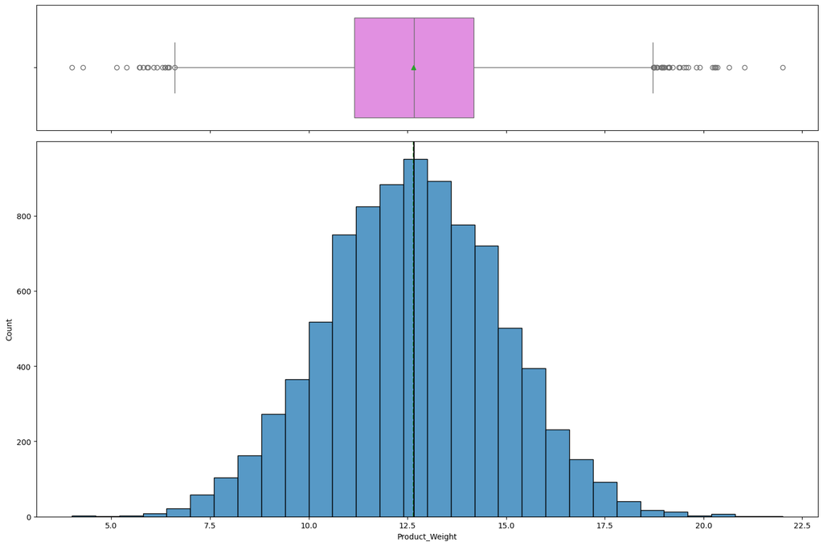

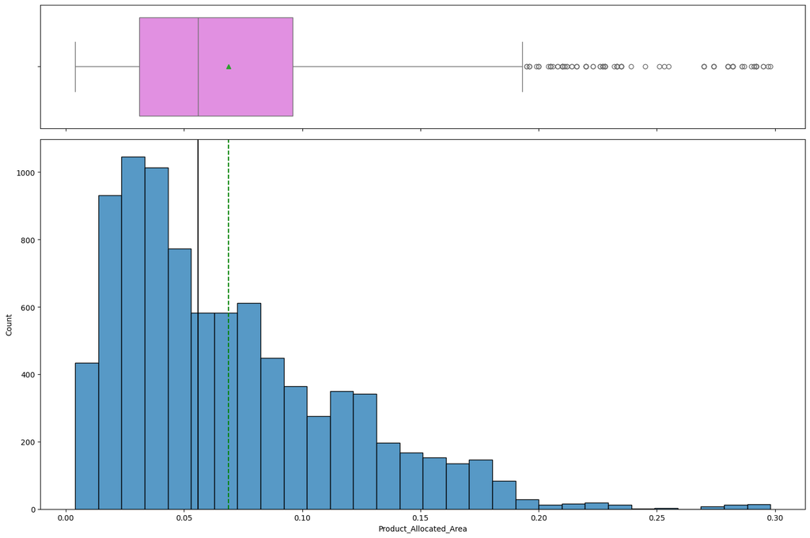

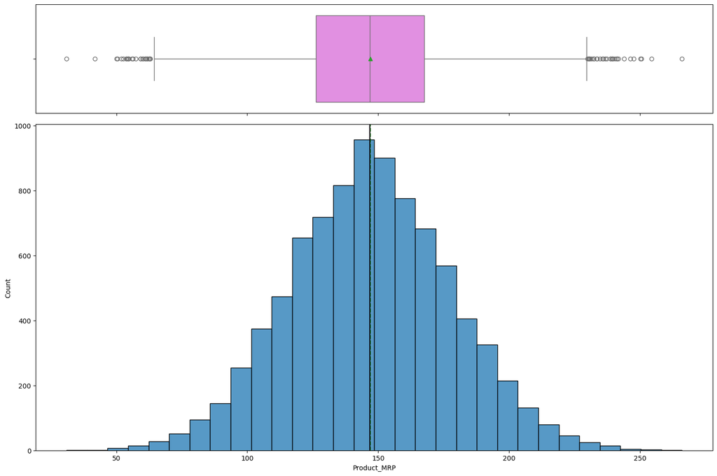

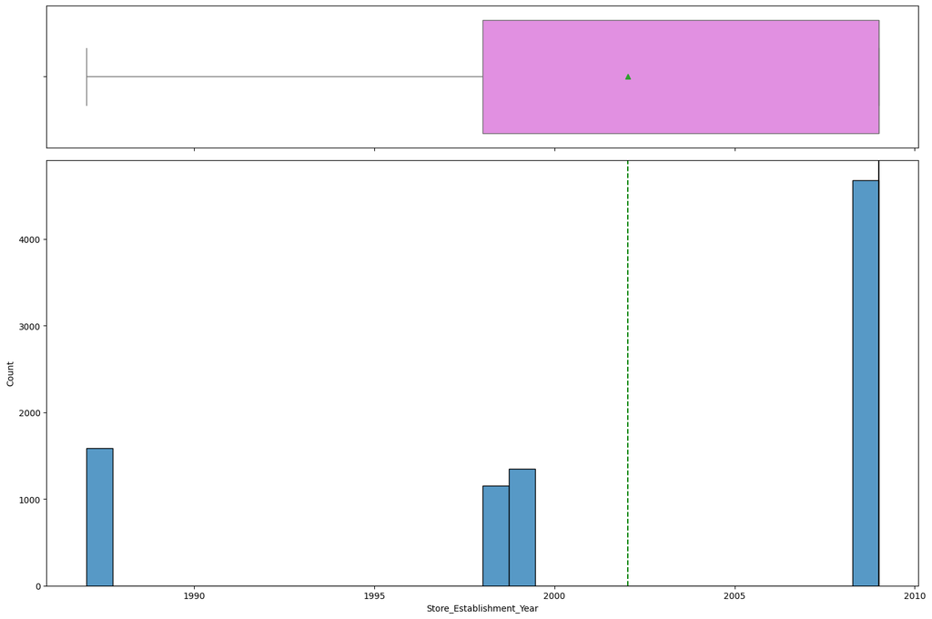

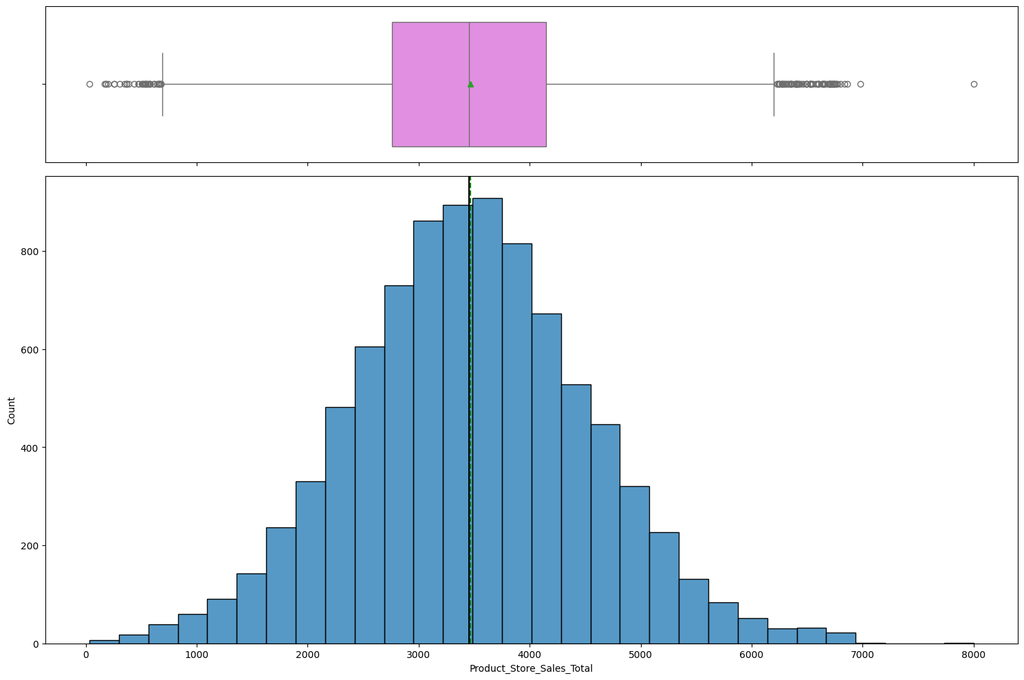

```python
histogram_boxplot(df, "Product_Weight")
histogram_boxplot(df, "Product_Allocated_Area")
histogram_boxplot(df, "Product_MRP")
histogram_boxplot(df, "Store_Establishment_Year")
histogram_boxplot(df, "Product_Store_Sales_Total")
```

```python
# function to create labeled barplots
import warnings
warnings.filterwarnings("ignore", category=FutureWarning)

def labeled_barplot(data, feature="", perc=True, n=5):
    """
    Barplot with percentage at the top

    data: dataframe
    feature: dataframe column
    perc: whether to display percentages instead of count (default is False)
    n: displays the top n category levels (default is None, i.e., display all levels)
    """

    total = len(data[feature])  # length of the column
    count = data[feature].nunique()
    if n is None:
        plt.figure(figsize=(count + 1, 5))
    else:
        plt.figure(figsize=(n + 1, 5))

    plt.xticks(rotation=90, fontsize=10)
    ax = sns.countplot(
        data=data,
        x=feature,
        palette="Paired",
        order=data[feature].value_counts().index[:n].sort_values(),
        hue=None,
        legend=False
    )

    for p in ax.patches:
        if perc == True:
            label = "{:.1f}%".format(
                100 * p.get_height() / total
            )  # percentage of each class of the category
        else:
            label = p.get_height()  # count of each level of the category

        x = p.get_x() + p.get_width() / 2  # width of the plot
        y = p.get_height()  # height of the plot

        ax.annotate(
            label,
            (x, y),
            ha="center",
            va="center",
            size=10,
            xytext=(0, 3),
            textcoords="offset points",
        )  # annotate the percentage

    plt.show()  # show the plot
```

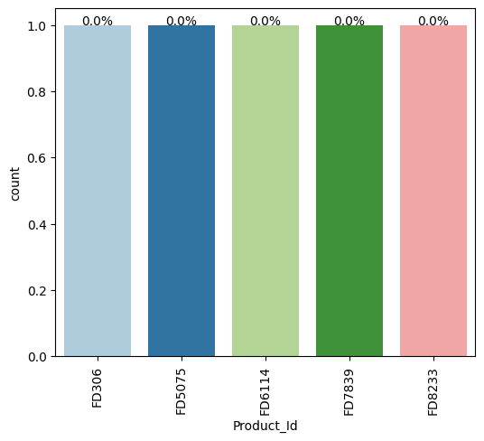

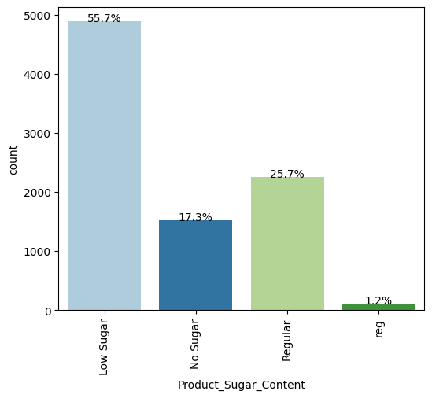

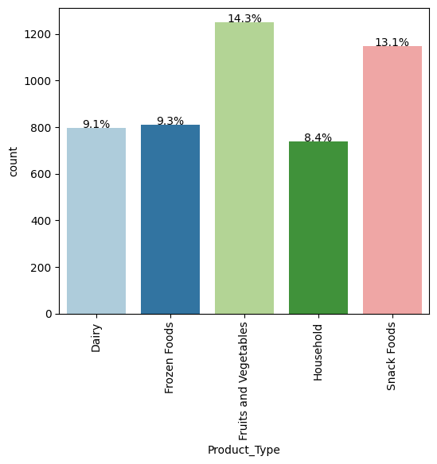

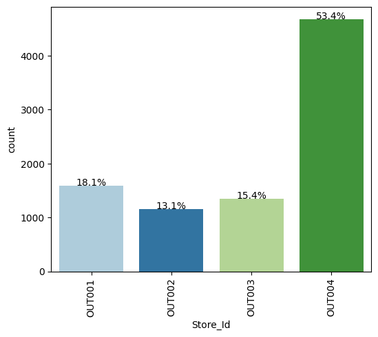

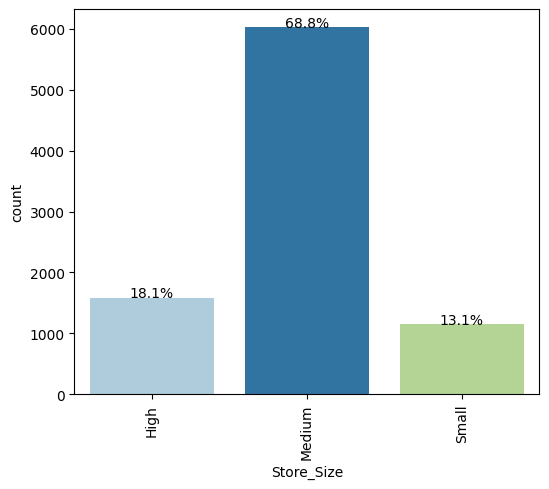

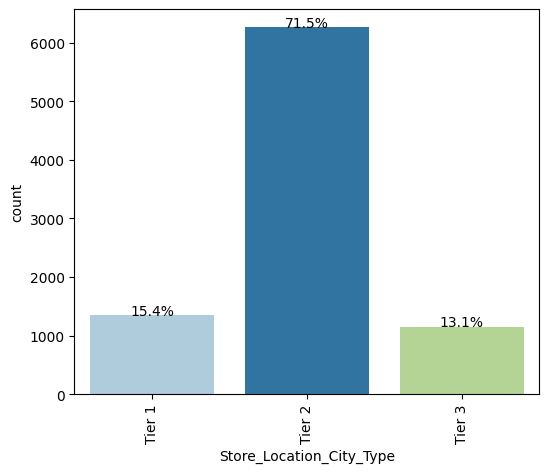

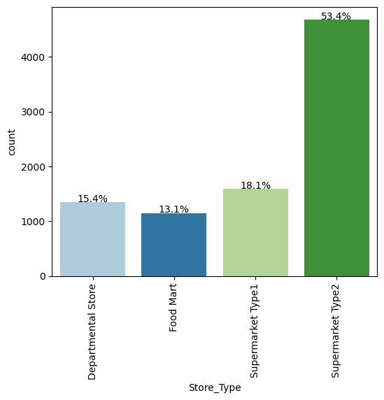

```python
labeled_barplot(df, "Product_Id")
labeled_barplot(df, "Product_Sugar_Content")
labeled_barplot(df, "Product_Type")
labeled_barplot(df, "Store_Id")
labeled_barplot(df, "Store_Size")
labeled_barplot(df, "Store_Location_City_Type")
labeled_barplot(df, "Store_Type")
```

### Observation:

Store_Establishment_Year is left-skewed, indicating that the majority of stores were established in more recent years, with no extreme outliers. Although outliers are detected in several numerical variables, they represent valid business cases (e.g., premium pricing, high shelf allocation, top-selling products) and therefore are retained.

## Bivariate Analysis

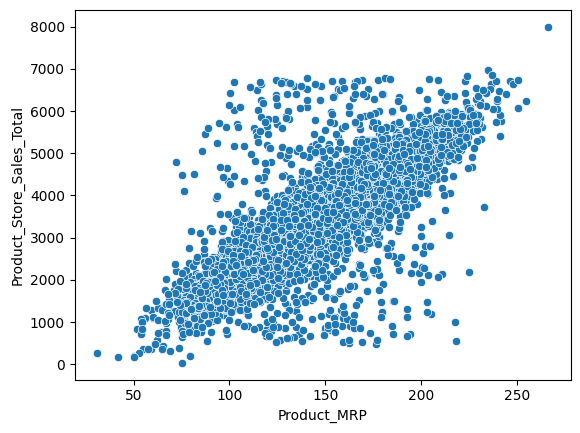

```python
# Sales vs Product MRP
sns.scatterplot(x='Product_MRP', y='Product_Store_Sales_Total', data=df)
plt.show()
```

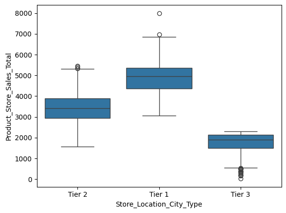

```python
# Sales by Store Location City Type
sns.boxplot(x='Store_Location_City_Type', y='Product_Store_Sales_Total', data=df)
plt.show()
```

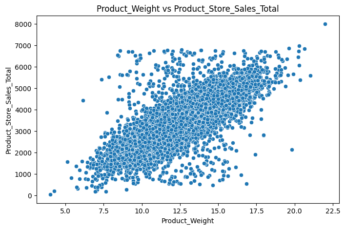

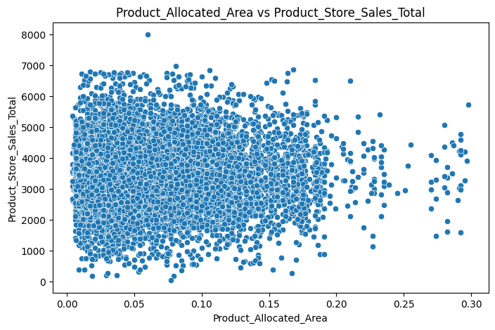

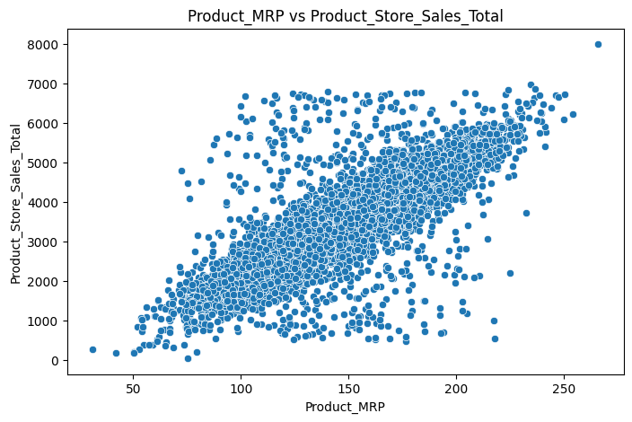

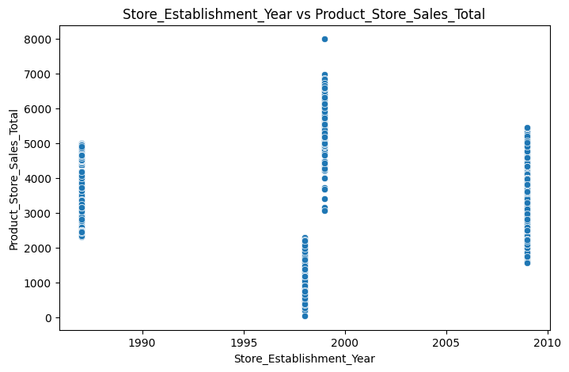

```python
# Numerical vs Numerical
num_features = [
    "Product_Weight",
    "Product_Allocated_Area",
    "Product_MRP",
    "Store_Establishment_Year"
]

target = "Product_Store_Sales_Total"

for feature in num_features:
    plt.figure(figsize=(8, 5))
    sns.scatterplot(x=df[feature], y=df[target])
    plt.title(f"{feature} vs {target}")
    plt.xlabel(feature)
    plt.ylabel(target)
    plt.show()
```